[figure not shown]

# Om data

### Indlæsning af data

```r
ex72<-read.table("../data/Ex72.txt",header=T)
head(ex72, 10)
```

```
   meat lab vita
1     1   1  2.3
2     1   1  1.9
3     1   2  1.5
4     1   2  1.1
5     1   3  1.1
6     1   3  1.1
7     1   4  1.4
8     1   4  1.4
9     1   5  1.2
10    1   5  1.1
```

Lav *meat* og *lab* om til faktorer

```r
ex72$meat<-factor(ex72$meat)
ex72$lab<-factor(ex72$lab)
```

### Undersøgelse af forsøgsdesign

```r
with(ex72, table(meat, lab))
```

```
    lab
meat 1 2 3 4 5
   1 2 2 2 2 2
   2 2 2 2 2 2
   3 2 2 2 2 2
   4 2 2 2 2 2
   5 2 2 2 2 2
```

Tabeller viser, at forsøget er et balanceret to-faktorforsøg med 2 gentagelser for hver kombination af faktorerne *meat* og *lab* som hver har 5 niveauer.

### Ny responsvariabel

Det viser sig, at det er hensigtsmæssigt at udføre analyserne med kvadratroden af Vitamin E indholdet som respons. Derfor lavet en ny variabel *svita*, der benyttes ved de efterfølgende statistiske analyser.

```r
ex72$svita <- sqrt(ex72$vita)
```

### Visualisering af data (kode)

```r
library(ggplot2)
ggplot(data = ex72) + geom_point(mapping = aes(x = meat, y = svita, color = lab)) +
  labs(y = "Square root of Vitamin (mg)", x = "Meat", title = "Vitamin E content in meat")
```

### Visualisering af data

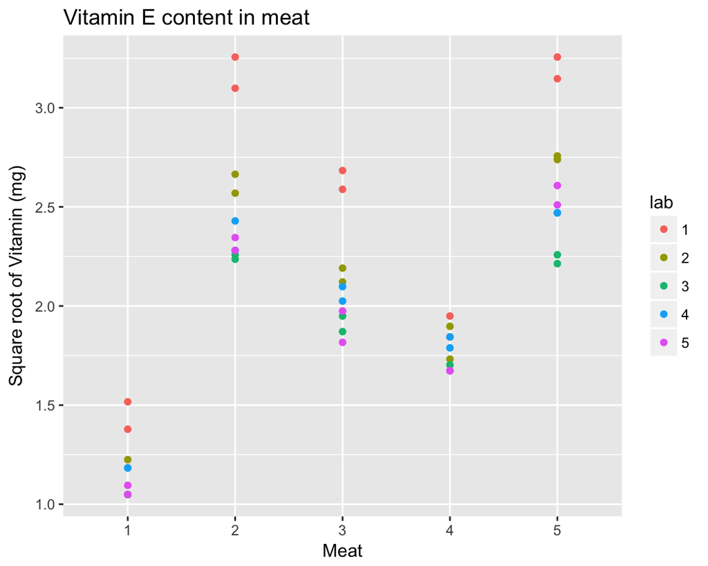

# Statistisk model med *lab* som tilfældig effekt

### Brug af lme()

I det følgende undersøges ved et likelihood-ratio test, om der er signifikant forskel på Vitamin E indholdet for de 5 niveauer af faktoren *meat*.

```r
library(nlme)
mod1 <- lme(svita ~ meat, random = ~1 | lab, method = "ML",ex72)
mod2 <- lme(svita ~ 1, random = ~1 | lab, method = "ML",ex72)
anova(mod2,mod1)
```

```
     Model df       AIC       BIC    logLik   Test  L.Ratio p-value
mod2     1  3  95.47071 101.20678 -44.73535
mod1     2  7 -30.57040 -17.18624  22.28520 1 vs 2 134.0411  <.0001
```

Likelihood-ratioteststørrelsen (=134.0411) oversættes til en approksimativ p-værdi (<.0001) ved at ‘slå op i’ en passende table over en chi-i-anden fordeling. Vi konkluderer, at der er signifikant forskel på Vitamin E indholdet i de 5 kødstykker (givet ved faktoren *meat*).

### Brug af lmer()

Modellerne og testet kan også fås frem ved at anvende *lmer()*-funktionen fra R-pakken *lme4*. Vær opmærksom på syntax-forskellene omkring

- hvordan man angiver tilfældige effekter i *lme* vs *lmer*
- hvordan man angiver om parametrene skal estimeres ved maksimum likelihood estimation eller ved REML-estimation i *lme* hhv *lmer*

Bemærk desuden, at teststørrelsen og p-værdien er ens uanset om man benytter *lme* eller *lmer*.

```r
library(lme4)
mod1alt <- lmer(svita ~ meat+(1|lab), REML = F, data = ex72)
mod2alt <- lmer(svita ~ 1+(1|lab), REML = F, data = ex72)
anova(mod2alt, mod1alt)
```

```
Data: ex72
Models:
mod2alt: svita ~ 1 + (1 | lab)
mod1alt: svita ~ meat + (1 | lab)
        Df     AIC     BIC  logLik deviance  Chisq Chi Df Pr(>Chisq)
mod2alt  3  95.471 101.207 -44.735   89.471
mod1alt  7 -30.570 -17.186  22.285  -44.570 134.04      4  < 2.2e-16 ***
---
Signif. codes:  0 '***' 0.001 '**' 0.01 '*' 0.05 '.' 0.1 ' ' 1
```

# Statistisk model med både *lab* og *lab x meat* som tilfældige effekter

I det følgende vises hvordan man ved brug af enten *lme* eller *lmer* kan lave en model med

- systematisk (=fixed) effekt af *meat*
- tilfældige (=random) effekt af både *lab* og *lab x meat*

Desuden produceres et likelihood ratio test for, om der er signifikante forskelle i Vitamin E indholdet for de 5 kødstykker givet ved faktoren *meat*.

### Med lme()

```r
library(nlme)
ex72$meatlab <- ex72$meat:ex72$lab
model1 <- lme(svita ~ meat, random = ~1 | lab/meatlab, method = "ML",ex72)
model2 <- lme(svita ~ 1, random = ~1 | lab/meatlab, method = "ML",ex72)
anova(model2, model1)
```

```
       Model df       AIC       BIC   logLik   Test  L.Ratio p-value
model2     1  4   6.47241  14.12050  0.76379
model1     2  8 -48.44624 -33.15005 32.22312 1 vs 2 62.91865  <.0001
```

Likelihood ratio teststørrelsen bliver 62.92 med en tilhørende p-værdi < 0.0001.

### Med lmer()

```r
model1alt <- lmer(svita ~ meat+(1|lab)+(1|meatlab), REML = F, data = ex72)
model2alt <- lmer(svita ~ 1+(1|lab)+(1|meatlab), REML = F, data = ex72)
anova(model2alt, model1alt)
```

```
Data: ex72
Models:
model2alt: svita ~ 1 + (1 | lab) + (1 | meatlab)
model1alt: svita ~ meat + (1 | lab) + (1 | meatlab)
          Df     AIC     BIC logLik deviance  Chisq Chi Df Pr(>Chisq)
model2alt  4   6.472  14.121  0.764   -1.528
model1alt  8 -48.446 -33.150 32.223  -64.446 62.919      4  7.059e-13 ***
---
Signif. codes:  0 '***' 0.001 '**' 0.01 '*' 0.05 '.' 0.1 ' ' 1
```

Likelihood ratio teststørrelsen bliver 62.92 med en tilhørende p-værdi < 0.0001.

# Statistisk model med 3 tilfældige effekter

Modellen med 3 tilfældige effekt af *lab*, *meat* og *lab x meat* estimeres lettest med *lmer* som vist nedenfor.

Vigtigt: Når man afrapporterer estimaterne for (varians)parametrene i en model med tilfældige effekter, så vil resultaterne være (lidt) afhængige af, om man bruge *ML* estimation eller *REML* estimation. Vi anbefaler, at man bruger *REML* estimation, hvilket i R-koden nedenfor angiver ved at skrive *REML = T*.

```r
r0 <- lmer(svita ~ 1 + (1|meat) + (1|lab) + (1|meatlab), REML = T, data = ex72)
r0
```

```
Linear mixed model fit by REML ['lmerMod']
Formula: svita ~ 1 + (1 | meat) + (1 | lab) + (1 | meatlab)
   Data: ex72
REML criterion at convergence: -39.453
Random effects:
 Groups   Name        Std.Dev.
 meatlab  (Intercept) 0.13470
 lab      (Intercept) 0.24521
 meat     (Intercept) 0.59546
 Residual             0.06774
Number of obs: 50, groups:  meatlab, 25; lab, 5; meat, 5
Fixed Effects:
(Intercept)
      2.054
```

Den statistiske model kan opskrives som

$$Y_i=\mu+ a({\tt meat}_i)+b({\tt lab}_i)+c({\tt lab \times meat}_i)+e_i,$$
hvor

- $a(1),\ldots,a(5)$ er uafhængige og $\sim N(0,\sigma^2_{meat})$
- $b(1),\ldots,b(5)$ er uafhængige og $\sim N(0,\sigma^2_{lab})$
- $c(1,1),\ldots,c(5,5)$ er uafhængige og $\sim N(0,\sigma^2_{lab \times meat})$
- $e_1,\ldots,e_{50}$ er uafhængige og $\sim N(0,\sigma^2)$

Varians-estimaterne svarende til de forskellige tilfældige effekt aflæses (let) under *Random effects* i udskriften ovenfor. F.eks ses, at estimatet for residualspredningen bliver $\hat{\sigma}=0.06774$